# Part II - Data Analysis/Data Visualization Report: Bike Ride Trends and Biker Types of Ford GoBike System

## Investigation Overview

This analysis explores Ford GoBike system trip data to understand key trends in bike ride duration and user demographics. It focuses on:

- Predicting trip duration using attributes like age, time (weekday, hour), user type, and gender.
- Providing insights into patterns in bike usage.

## Dataset Overview and Executive Summary

This document explores the Ford GoBike's trip data for public containing bike rides . The attributes included the trip start/end time, as well as additional measurements such as user type, gender, and age. 13K data points were removed from the analysis due to missing values in some fields, data inconsistent, or outliner issues.

|  | duration_sec | start_time | end_time | start_station_id | start_station_name | start_station_latitude | start_station_longitude | end_station_id | end_station_name | end_station_latitude | end_station_longitude | bike_id | user_type | member_birth_year | member_gender | bike_share_for_all_trip | start_time_dayofweek | start_time_hour | member_age | log_duration_sec |
| --- | --- | --- | --- | --- | --- | --- | --- | --- | --- | --- | --- | --- | --- | --- | --- | --- | --- | --- | --- | --- |
| 0 | 1585 | 2019-02-28 23:54:18.549 | 2019-03-01 00:20:44.074 | 7.0 | Frank H Ogawa Plaza | 37.804562 | -122.271738 | 222.0 | 10th Ave at E 15th St | 37.792714 | -122.248780 | 4898 | Subscriber | 1974 | Male | True | Thu | 23 | 45 | 3.200029 |
| 1 | 1793 | 2019-02-28 23:49:58.632 | 2019-03-01 00:19:51.760 | 93.0 | 4th St at Mission Bay Blvd S | 37.770407 | -122.391198 | 323.0 | Broadway at Kearny | 37.798014 | -122.405950 | 5200 | Subscriber | 1959 | Male | False | Thu | 23 | 60 | 3.253580 |
| 2 | 1147 | 2019-02-28 23:55:35.104 | 2019-03-01 00:14:42.588 | 300.0 | Palm St at Willow St | 37.317298 | -121.884995 | 312.0 | San Jose Diridon Station | 37.329732 | -121.901782 | 3803 | Subscriber | 1983 | Female | False | Thu | 23 | 36 | 3.059563 |
| 3 | 1615 | 2019-02-28 23:41:06.766 | 2019-03-01 00:08:02.756 | 10.0 | Washington St at Kearny St | 37.795393 | -122.404770 | 127.0 | Valencia St at 21st St | 37.756708 | -122.421025 | 6329 | Subscriber | 1989 | Male | False | Thu | 23 | 30 | 3.208173 |
| 4 | 1570 | 2019-02-28 23:41:48.790 | 2019-03-01 00:07:59.715 | 10.0 | Washington St at Kearny St | 37.795393 | -122.404770 | 127.0 | Valencia St at 21st St | 37.756708 | -122.421025 | 6548 | Subscriber | 1988 | Other | False | Thu | 23 | 31 | 3.195900 |

```
<class 'pandas.core.frame.DataFrame'>
RangeIndex: 170557 entries, 0 to 170556
Data columns (total 20 columns):
 #   Column                   Non-Null Count   Dtype
---  ------                   --------------   -----
 0   duration_sec             170557 non-null  int64
 1   start_time               170557 non-null  object
 2   end_time                 170557 non-null  object
 3   start_station_id         170557 non-null  float64
 4   start_station_name       170557 non-null  object
 5   start_station_latitude   170557 non-null  float64
 6   start_station_longitude  170557 non-null  float64
 7   end_station_id           170557 non-null  float64
 8   end_station_name         170557 non-null  object
 9   end_station_latitude     170557 non-null  float64
 10  end_station_longitude    170557 non-null  float64
 11  bike_id                  170557 non-null  int64
 12  user_type                170557 non-null  object
 13  member_birth_year        170557 non-null  int64
 14  member_gender            170557 non-null  object
 15  bike_share_for_all_trip  170557 non-null  bool
 16  start_time_dayofweek     170557 non-null  object
 17  start_time_hour          170557 non-null  int64
 18  member_age               170557 non-null  int64
 19  log_duration_sec         170557 non-null  float64
dtypes: bool(1), float64(7), int64(5), object(7)
memory usage: 24.9+ MB
```

```
<class 'pandas.core.frame.DataFrame'>
RangeIndex: 170557 entries, 0 to 170556
Data columns (total 20 columns):
 #   Column                   Non-Null Count   Dtype
---  ------                   --------------   -----
 0   duration_sec             170557 non-null  int64
 1   start_time               170557 non-null  datetime64[ns]
 2   end_time                 170557 non-null  datetime64[ns]
 3   start_station_id         170557 non-null  float64
 4   start_station_name       170557 non-null  object
 5   start_station_latitude   170557 non-null  float64
 6   start_station_longitude  170557 non-null  float64
 7   end_station_id           170557 non-null  float64
 8   end_station_name         170557 non-null  object
 9   end_station_latitude     170557 non-null  float64
 10  end_station_longitude    170557 non-null  float64
 11  bike_id                  170557 non-null  int64
 12  user_type                170557 non-null  category
 13  member_birth_year        170557 non-null  int64
 14  member_gender            170557 non-null  category
 15  bike_share_for_all_trip  170557 non-null  bool
 16  start_time_dayofweek     170557 non-null  category
 17  start_time_hour          170557 non-null  category
 18  member_age               170557 non-null  int64
 19  log_duration_sec         170557 non-null  float64
dtypes: bool(1), category(4), datetime64[ns](2), float64(7), int64(4), object(2)
memory usage: 20.3+ MB
```

## Visualization 1 :- Distribution of Trip Durations

**Description**

- This histogram displays the distribution of trip durations across all rides.

**Clarifications**

- Most trips are short, with the majority below 10,000 seconds (approx. 2.8 hours).
- The distribution has a long tail, indicating a small number of very long rides.

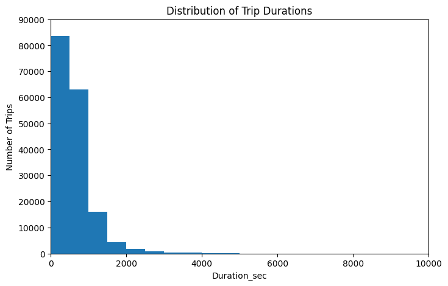

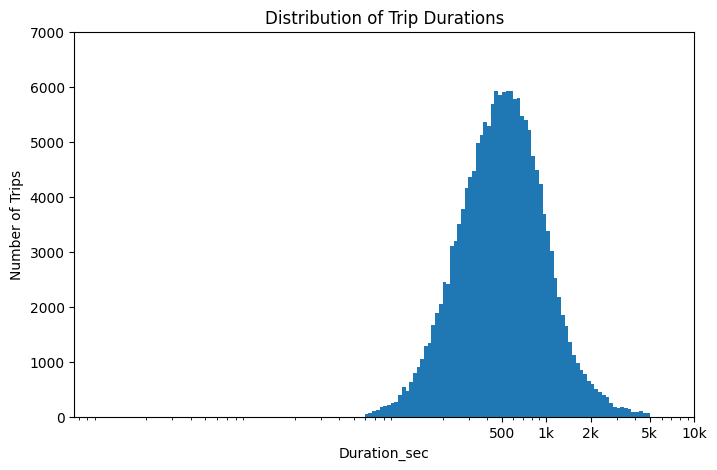

## Visualization 2 :- Distribution of User Ages

**Description**

- This histogram illustrates the age distribution of users.

**Clarifications**

- The majority of users are in the 20–40 age range.
- Fewer users are older than 60.

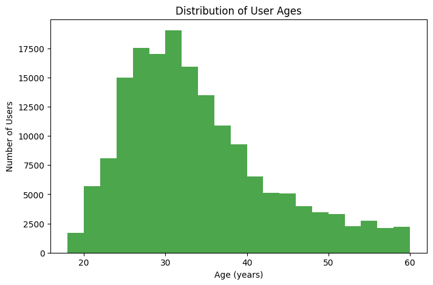

## Visualization 3 :- Trip Count by Hour, User Type, and Gender

**Description**

- This multi-plot visualization compares trip counts by:
  - Start time (hour)
  - User type (subscriber or customer)
  - Gender

**Clarifications**

- Peak usage occurs during commuting hours (7–9 AM, 5–7 PM).
- Subscribers dominate peak periods, reflecting regular commuter patterns.
- Gender differences are visible, with more male riders overall.

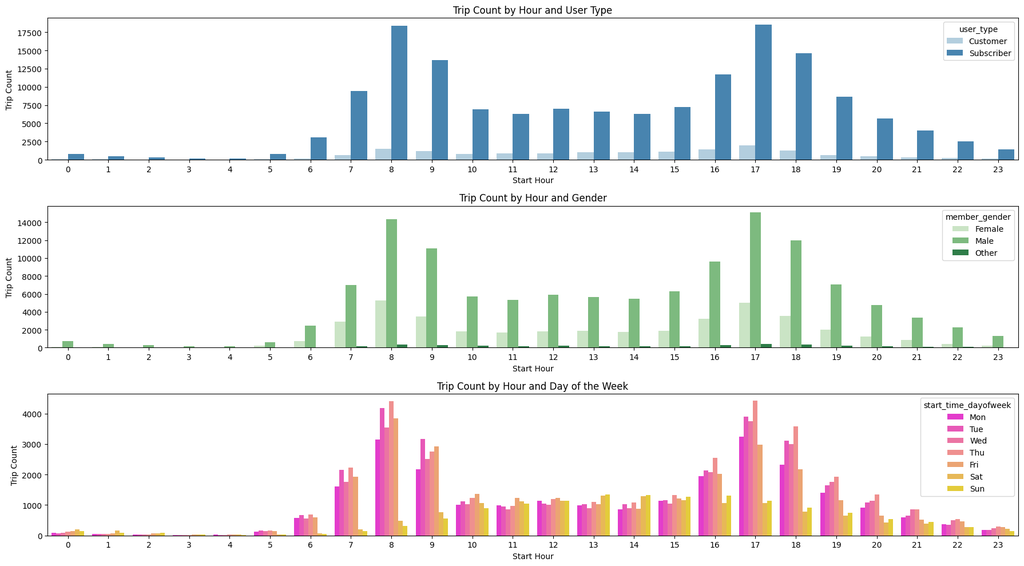

## Visualization 4 :- Age vs. Trip Duration

**Description**

- Scatter plots and heatmaps illustrate the relationship between age and trip duration.

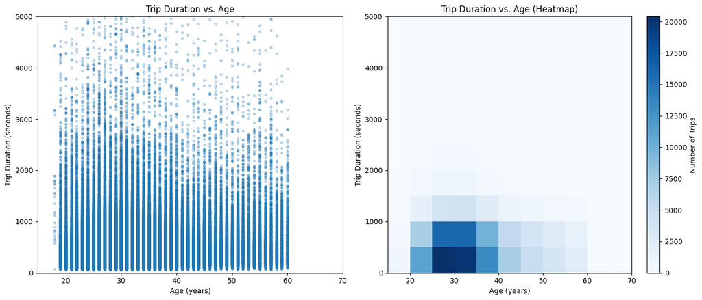

## (Visualization 5 :- Hourly Trip Durations by Age Group

**Description**

- Point plots show variations in average trip duration for users under and over 40 years of age.

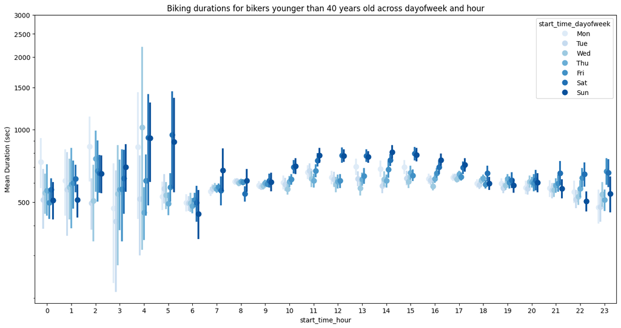

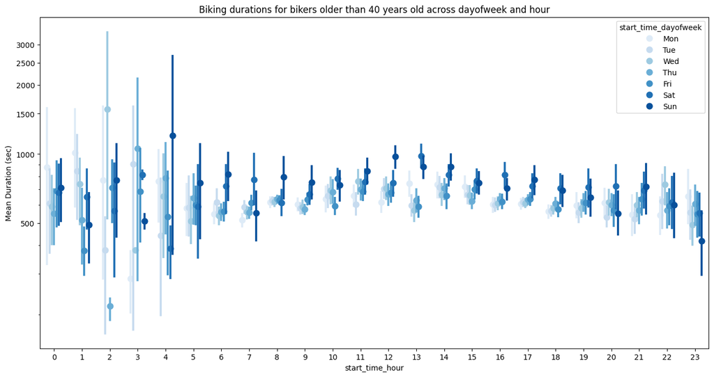

## Visualization 6 :- Trip Duration and Age by Gender

The main thing I want to explore in this part of the analysis is how the three categorical measures of gender into the relationship between trip duration and age.

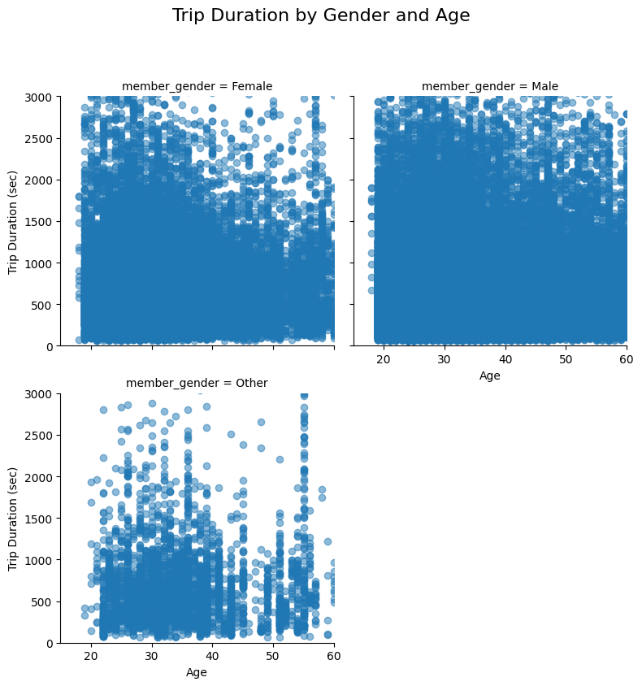

## Visualization 7 :- Trip Duration and Age by User Type

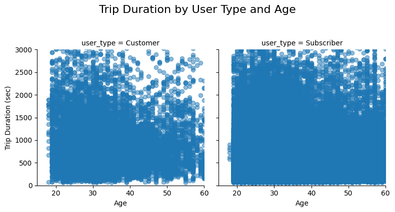

[output not shown]